# examples_0326

Let set $A$ and set $B$ represent collections of lower-case letters:

$$A=\{j,\,u,\,s,\,y,\,g,\,a,\,v,\,i,\,p,\,z\}$$
$$B=\{x,\,i,\,s,\,m,\,n\}$$

Calculate the following [cardinalities](https://en.wikipedia.org/wiki/Cardinality):

- $n(A)=$
- $n(B)=$
- $n(A\cap B)=$
- $n(A\cup B)=$

Set $A$ has 10 elements.
$$n(A)=10$$

Set $B$ has 5 elements.
$$n(B)=5$$

Next, identify the intersection. What elements are common to both sets?

$$A\cap B ~=~ \{s,\,i\}$$

Set $A\cap B$ has 2 elements.
$$n(A\cap B)=2$$

Next, you could try writing out all elements of the union.

$$A\cup B ~=~
\{g,\,a,\,n,\,s,\,x,\,j,\,y,\,v,\,p,\,i,\,m,\,u,\,z\}$$

However, it is probably easier to use the [inclusion-exclusion principle](https://en.wikipedia.org/wiki/Inclusion%E2%80%93exclusion_principle):

$$n(A\cup B)~=~n(A)+n(B)-n(A\cap
B)$$
$$n(A\cup B)~=~10+5-2$$
$$n(A\cup B)~=~13$$

Let set $A$ and set $B$ represent collections of lower-case letters:

$$A=\{j,\,q,\,u,\,h,\,i,\,c,\,n,\,d,\,p\}$$
$$B=\{d,\,z,\,p,\,h,\,j,\,t,\,u\}$$

Calculate the following [cardinalities](https://en.wikipedia.org/wiki/Cardinality):

- $n(A)=$
- $n(B)=$
- $n(A\cap B)=$
- $n(A\cup B)=$

Set $A$ has 9 elements.
$$n(A)=9$$

Set $B$ has 7 elements.
$$n(B)=7$$

Next, identify the intersection. What elements are common to both sets?

$$A\cap B ~=~
\{h,\,p,\,d,\,j,\,u\}$$

Set $A\cap B$ has 5 elements.
$$n(A\cap B)=5$$

Next, you could try writing out all elements of the union.

$$A\cup B ~=~
\{q,\,c,\,z,\,n,\,p,\,h,\,t,\,u,\,j,\,d,\,i\}$$

However, it is probably easier to use the [inclusion-exclusion principle](https://en.wikipedia.org/wiki/Inclusion%E2%80%93exclusion_principle):

$$n(A\cup B)~=~n(A)+n(B)-n(A\cap
B)$$
$$n(A\cup B)~=~9+7-5$$
$$n(A\cup B)~=~11$$

Let set $A$ and set $B$ represent collections of lower-case letters:

$$A=\{z,\,p,\,i,\,a,\,y,\,g,\,j,\,k,\,w,\,v\}$$
$$B=\{v,\,s,\,i,\,g,\,x,\,w\}$$

Calculate the following [cardinalities](https://en.wikipedia.org/wiki/Cardinality):

- $n(A)=$
- $n(B)=$
- $n(A\cap B)=$
- $n(A\cup B)=$

Set $A$ has 10 elements.
$$n(A)=10$$

Set $B$ has 6 elements.
$$n(B)=6$$

Next, identify the intersection. What elements are common to both sets?

$$A\cap B ~=~
\{w,\,i,\,v,\,g\}$$

Set $A\cap B$ has 4 elements.
$$n(A\cap B)=4$$

Next, you could try writing out all elements of the union.

$$A\cup B ~=~
\{p,\,y,\,j,\,s,\,x,\,v,\,a,\,g,\,z,\,i,\,k,\,w\}$$

However, it is probably easier to use the [inclusion-exclusion principle](https://en.wikipedia.org/wiki/Inclusion%E2%80%93exclusion_principle):

$$n(A\cup B)~=~n(A)+n(B)-n(A\cap
B)$$
$$n(A\cup B)~=~10+6-4$$
$$n(A\cup B)~=~12$$

Let set $A$ and set $B$ represent collections of lower-case letters:

$$A=\{t,\,r,\,e,\,z,\,v,\,o,\,f,\,k\}$$
$$B=\{o,\,p,\,u,\,d,\,r,\,v\}$$

Calculate the following [cardinalities](https://en.wikipedia.org/wiki/Cardinality):

- $n(A)=$
- $n(B)=$
- $n(A\cap B)=$
- $n(A\cup B)=$

Set $A$ has 8 elements.
$$n(A)=8$$

Set $B$ has 6 elements.
$$n(B)=6$$

Next, identify the intersection. What elements are common to both sets?

$$A\cap B ~=~ \{r,\,v,\,o\}$$

Set $A\cap B$ has 3 elements.
$$n(A\cap B)=3$$

Next, you could try writing out all elements of the union.

$$A\cup B ~=~
\{d,\,z,\,t,\,e,\,f,\,o,\,v,\,u,\,p,\,k,\,r\}$$

However, it is probably easier to use the [inclusion-exclusion principle](https://en.wikipedia.org/wiki/Inclusion%E2%80%93exclusion_principle):

$$n(A\cup B)~=~n(A)+n(B)-n(A\cap
B)$$
$$n(A\cup B)~=~8+6-3$$
$$n(A\cup B)~=~11$$

Let set $A$ and set $B$ represent collections of lower-case letters:

$$A=\{r,\,x,\,e,\,d,\,j,\,y,\,c,\,a\}$$
$$B=\{p,\,x,\,t,\,h,\,r,\,c,\,k,\,l,\,a\}$$

Calculate the following [cardinalities](https://en.wikipedia.org/wiki/Cardinality):

- $n(A)=$
- $n(B)=$
- $n(A\cap B)=$
- $n(A\cup B)=$

Set $A$ has 8 elements.
$$n(A)=8$$

Set $B$ has 9 elements.
$$n(B)=9$$

Next, identify the intersection. What elements are common to both sets?

$$A\cap B ~=~
\{a,\,x,\,c,\,r\}$$

Set $A\cap B$ has 4 elements.
$$n(A\cap B)=4$$

Next, you could try writing out all elements of the union.

$$A\cup B ~=~
\{d,\,l,\,c,\,r,\,y,\,t,\,e,\,k,\,a,\,j,\,p,\,x,\,h\}$$

However, it is probably easier to use the [inclusion-exclusion principle](https://en.wikipedia.org/wiki/Inclusion%E2%80%93exclusion_principle):

$$n(A\cup B)~=~n(A)+n(B)-n(A\cap
B)$$
$$n(A\cup B)~=~8+9-4$$
$$n(A\cup B)~=~13$$

Let set $A$ and set $B$ represent collections of lower-case letters:

$$A=\{s,\,i,\,h\}$$
$$B=\{p,\,m,\,s,\,i\}$$

Calculate the following [cardinalities](https://en.wikipedia.org/wiki/Cardinality):

- $n(A)=$
- $n(B)=$
- $n(A\cap B)=$
- $n(A\cup B)=$

Set $A$ has 3 elements.
$$n(A)=3$$

Set $B$ has 4 elements.
$$n(B)=4$$

Next, identify the intersection. What elements are common to both sets?

$$A\cap B ~=~ \{i,\,s\}$$

Set $A\cap B$ has 2 elements.
$$n(A\cap B)=2$$

Next, you could try writing out all elements of the union.

$$A\cup B ~=~
\{h,\,i,\,m,\,s,\,p\}$$

However, it is probably easier to use the [inclusion-exclusion principle](https://en.wikipedia.org/wiki/Inclusion%E2%80%93exclusion_principle):

$$n(A\cup B)~=~n(A)+n(B)-n(A\cap
B)$$
$$n(A\cup B)~=~3+4-2$$
$$n(A\cup B)~=~5$$

Let set $A$ and set $B$ represent collections of lower-case letters:

$$A=\{i,\,l,\,e,\,h,\,z,\,d,\,w,\,q,\,n\}$$
$$B=\{t,\,y,\,n,\,e,\,j,\,w,\,k,\,i,\,d,\,o\}$$

Calculate the following [cardinalities](https://en.wikipedia.org/wiki/Cardinality):

- $n(A)=$
- $n(B)=$
- $n(A\cap B)=$
- $n(A\cup B)=$

Set $A$ has 9 elements.
$$n(A)=9$$

Set $B$ has 10 elements.
$$n(B)=10$$

Next, identify the intersection. What elements are common to both sets?

$$A\cap B ~=~
\{e,\,i,\,n,\,w,\,d\}$$

Set $A\cap B$ has 5 elements.
$$n(A\cap B)=5$$

Next, you could try writing out all elements of the union.

$$A\cup B ~=~
\{o,\,d,\,i,\,y,\,w,\,q,\,n,\,e,\,l,\,t,\,h,\,k,\,z,\,j\}$$

However, it is probably easier to use the [inclusion-exclusion principle](https://en.wikipedia.org/wiki/Inclusion%E2%80%93exclusion_principle):

$$n(A\cup B)~=~n(A)+n(B)-n(A\cap
B)$$
$$n(A\cup B)~=~9+10-5$$
$$n(A\cup B)~=~14$$

Let set $A$ and set $B$ represent collections of lower-case letters:

$$A=\{u,\,e,\,x,\,q,\,c,\,r,\,f,\,h,\,t,\,i\}$$
$$B=\{x,\,u,\,r,\,e,\,k,\,h\}$$

Calculate the following [cardinalities](https://en.wikipedia.org/wiki/Cardinality):

- $n(A)=$
- $n(B)=$
- $n(A\cap B)=$
- $n(A\cup B)=$

Set $A$ has 10 elements.
$$n(A)=10$$

Set $B$ has 6 elements.
$$n(B)=6$$

Next, identify the intersection. What elements are common to both sets?

$$A\cap B ~=~
\{u,\,h,\,x,\,r,\,e\}$$

Set $A\cap B$ has 5 elements.
$$n(A\cap B)=5$$

Next, you could try writing out all elements of the union.

$$A\cup B ~=~
\{e,\,u,\,h,\,x,\,f,\,r,\,t,\,i,\,k,\,q,\,c\}$$

However, it is probably easier to use the [inclusion-exclusion principle](https://en.wikipedia.org/wiki/Inclusion%E2%80%93exclusion_principle):

$$n(A\cup B)~=~n(A)+n(B)-n(A\cap
B)$$
$$n(A\cup B)~=~10+6-5$$
$$n(A\cup B)~=~11$$

Let set $A$ and set $B$ represent collections of lower-case letters:

$$A=\{x,\,t,\,z,\,m,\,a,\,n,\,u\}$$
$$B=\{r,\,x,\,y,\,h,\,z,\,m,\,u,\,l,\,d\}$$

Calculate the following [cardinalities](https://en.wikipedia.org/wiki/Cardinality):

- $n(A)=$
- $n(B)=$
- $n(A\cap B)=$
- $n(A\cup B)=$

Set $A$ has 7 elements.
$$n(A)=7$$

Set $B$ has 9 elements.
$$n(B)=9$$

Next, identify the intersection. What elements are common to both sets?

$$A\cap B ~=~
\{m,\,x,\,z,\,u\}$$

Set $A\cap B$ has 4 elements.
$$n(A\cap B)=4$$

Next, you could try writing out all elements of the union.

$$A\cup B ~=~
\{a,\,x,\,u,\,t,\,y,\,l,\,h,\,r,\,d,\,z,\,n,\,m\}$$

However, it is probably easier to use the [inclusion-exclusion principle](https://en.wikipedia.org/wiki/Inclusion%E2%80%93exclusion_principle):

$$n(A\cup B)~=~n(A)+n(B)-n(A\cap
B)$$
$$n(A\cup B)~=~7+9-4$$
$$n(A\cup B)~=~12$$

Let set $A$ and set $B$ represent collections of lower-case letters:

$$A=\{j,\,x,\,l,\,b,\,k,\,h\}$$
$$B=\{b,\,o,\,m,\,e,\,p,\,k,\,h,\,z\}$$

Calculate the following [cardinalities](https://en.wikipedia.org/wiki/Cardinality):

- $n(A)=$
- $n(B)=$
- $n(A\cap B)=$
- $n(A\cup B)=$

Set $A$ has 6 elements.
$$n(A)=6$$

Set $B$ has 8 elements.
$$n(B)=8$$

Next, identify the intersection. What elements are common to both sets?

$$A\cap B ~=~ \{h,\,k,\,b\}$$

Set $A\cap B$ has 3 elements.
$$n(A\cap B)=3$$

Next, you could try writing out all elements of the union.

$$A\cup B ~=~
\{z,\,p,\,k,\,b,\,l,\,o,\,h,\,x,\,e,\,m,\,j\}$$

However, it is probably easier to use the [inclusion-exclusion principle](https://en.wikipedia.org/wiki/Inclusion%E2%80%93exclusion_principle):

$$n(A\cup B)~=~n(A)+n(B)-n(A\cap
B)$$
$$n(A\cup B)~=~6+8-3$$
$$n(A\cup B)~=~11$$

Let set $S$ represent a collection of lower-case letters:

$$S=\{y,\,s,\,l,\,b,\,h,\,g,\,k,\,t,\,a\}$$

Calculate the number of **proper** subsets of $S$.

Set $S$ has 9 elements.

$$n(S)~=~9$$

The formula for the number of subsets is $2^{n(S)}$. But that includes $S$, which is not a proper subset of itself, so we need to subtract 1 to find the number of **proper** subsets.

$$2^{9}-1=511$$

We could get fancy...

$$n(\{A|A\subset
S\})~=~2^{n(S)}-1$$

Let set $S$ represent a collection of lower-case letters:

$$S=\{g,\,q,\,l,\,y,\,w,\,d,\,z,\,t\}$$

Calculate the number of **proper** subsets of $S$.

Set $S$ has 8 elements.

$$n(S)~=~8$$

The formula for the number of subsets is $2^{n(S)}$. But that includes $S$, which is not a proper subset of itself, so we need to subtract 1 to find the number of **proper** subsets.

$$2^{8}-1=255$$

We could get fancy...

$$n(\{A|A\subset
S\})~=~2^{n(S)}-1$$

Let set $S$ represent a collection of lower-case letters:

$$S=\{p,\,t,\,m,\,r\}$$

Calculate the number of **proper** subsets of $S$.

Set $S$ has 4 elements.

$$n(S)~=~4$$

The formula for the number of subsets is $2^{n(S)}$. But that includes $S$, which is not a proper subset of itself, so we need to subtract 1 to find the number of **proper** subsets.

$$2^{4}-1=15$$

We could get fancy...

$$n(\{A|A\subset
S\})~=~2^{n(S)}-1$$

Let set $S$ represent a collection of lower-case letters:

$$S=\{p,\,w,\,o,\,q,\,x,\,c\}$$

Calculate the number of **proper** subsets of $S$.

Set $S$ has 6 elements.

$$n(S)~=~6$$

The formula for the number of subsets is $2^{n(S)}$. But that includes $S$, which is not a proper subset of itself, so we need to subtract 1 to find the number of **proper** subsets.

$$2^{6}-1=63$$

We could get fancy...

$$n(\{A|A\subset
S\})~=~2^{n(S)}-1$$

Let set $S$ represent a collection of lower-case letters:

$$S=\{r,\,n,\,w\}$$

Calculate the number of subsets of $S$.

Set $S$ has 3 elements.

$$n(S)~=~3$$

The formula for the number of subsets is $2^{n(S)}$.

$$2^{3}=8$$

Let set $S$ represent a collection of lower-case letters:

$$S=\{s,\,o,\,p,\,z,\,u\}$$

Calculate the number of **proper** subsets of $S$.

Set $S$ has 5 elements.

$$n(S)~=~5$$

The formula for the number of subsets is $2^{n(S)}$. But that includes $S$, which is not a proper subset of itself, so we need to subtract 1 to find the number of **proper** subsets.

$$2^{5}-1=31$$

We could get fancy...

$$n(\{A|A\subset
S\})~=~2^{n(S)}-1$$

Let set $S$ represent a collection of lower-case letters:

$$S=\{l,\,w,\,k,\,i,\,t,\,r,\,j,\,g\}$$

Calculate the number of subsets of $S$.

Set $S$ has 8 elements.

$$n(S)~=~8$$

The formula for the number of subsets is $2^{n(S)}$.

$$2^{8}=256$$

Let set $S$ represent a collection of lower-case letters:

$$S=\{e,\,y,\,f,\,i,\,x,\,s\}$$

Calculate the number of subsets of $S$.

Set $S$ has 6 elements.

$$n(S)~=~6$$

The formula for the number of subsets is $2^{n(S)}$.

$$2^{6}=64$$

Let set $S$ represent a collection of lower-case letters:

$$S=\{e,\,n,\,s,\,u,\,v,\,p,\,l\}$$

Calculate the number of subsets of $S$.

Set $S$ has 7 elements.

$$n(S)~=~7$$

The formula for the number of subsets is $2^{n(S)}$.

$$2^{7}=128$$

Let set $S$ represent a collection of lower-case letters:

$$S=\{x,\,u,\,n,\,b,\,y,\,i,\,s,\,d,\,v,\,q\}$$

Calculate the number of **proper** subsets of $S$.

Set $S$ has 10 elements.

$$n(S)~=~10$$

The formula for the number of subsets is $2^{n(S)}$. But that includes $S$, which is not a proper subset of itself, so we need to subtract 1 to find the number of **proper** subsets.

$$2^{10}-1=1023$$

We could get fancy...

$$n(\{A|A\subset
S\})~=~2^{n(S)}-1$$

There are 27 tokens organized by 2 (not visible) attributes. Tokens with those attributes are categorized into subsets $A$ and $B$. Those subsets are visualized with a Venn diagram below. Each region's cardinality is shown.

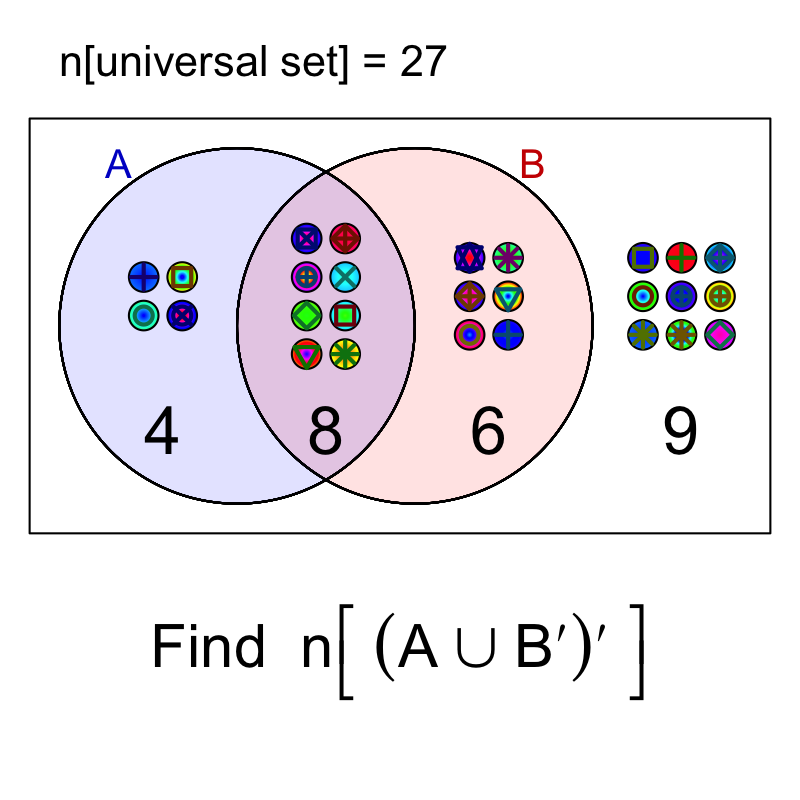

Find $n((A ∪ B')')$.

The answer is 6.

There are 26 tokens organized by 2 (not visible) attributes. Tokens with those attributes are categorized into subsets $A$ and $B$. Those subsets are visualized with a Venn diagram below. Each region's cardinality is shown.

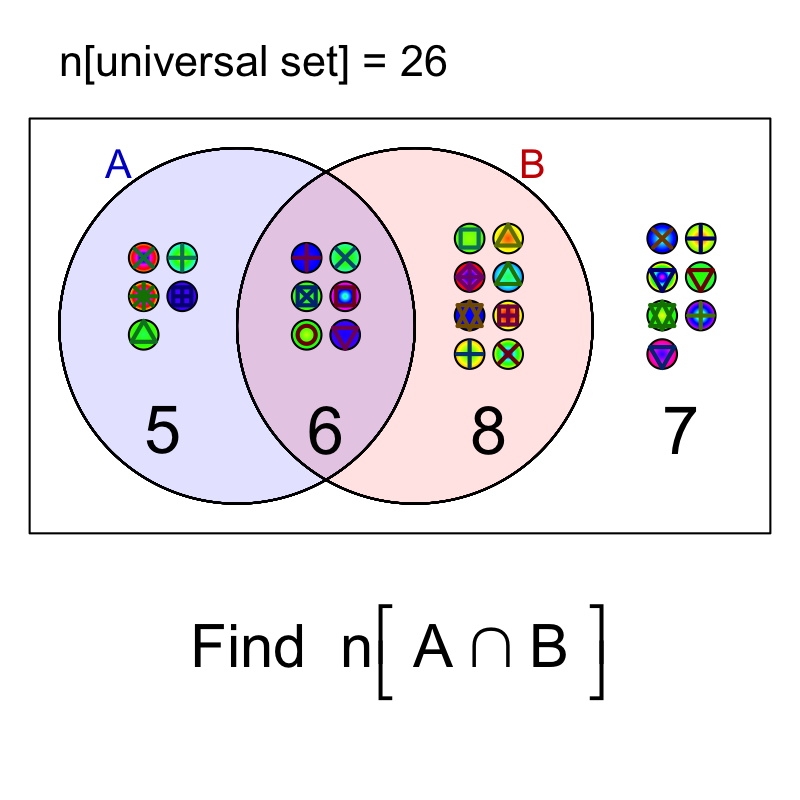

Find $n(A ∩ B)$.

The answer is 6.

There are 20 tokens organized by 2 (not visible) attributes. Tokens with those attributes are categorized into subsets $A$ and $B$. Those subsets are visualized with a Venn diagram below. Each region's cardinality is shown.

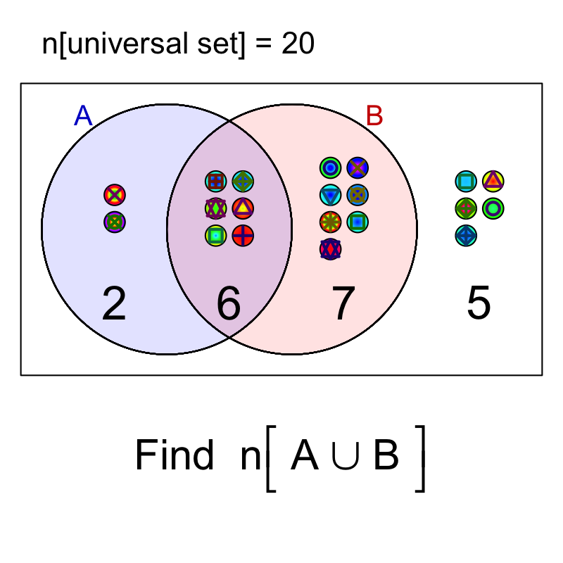

Find $n(A ∪ B)$.

The answer is 15.

There are 38 tokens organized by 2 (not visible) attributes. Tokens with those attributes are categorized into subsets $A$ and $B$. Those subsets are visualized with a Venn diagram below. Each region's cardinality is shown.

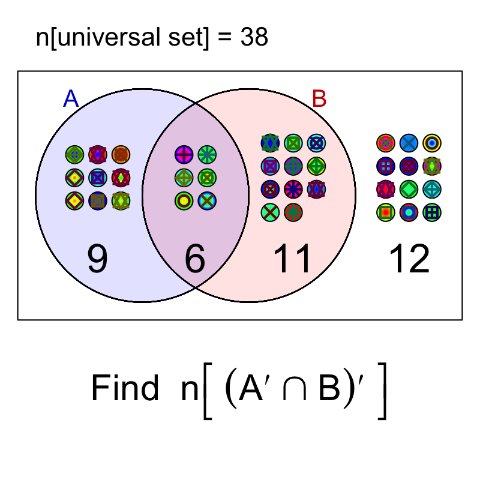

Find $n((A' ∩ B)')$.

The answer is 27.

There are 31 tokens organized by 2 (not visible) attributes. Tokens with those attributes are categorized into subsets $A$ and $B$. Those subsets are visualized with a Venn diagram below. Each region's cardinality is shown.

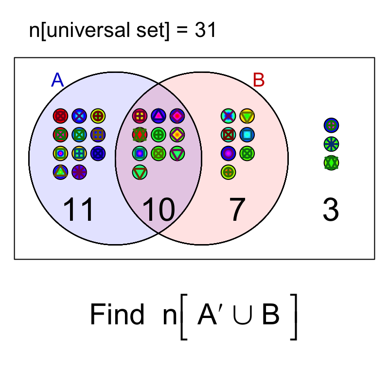

Find $n(A' ∪ B)$.

The answer is 20.

There are 27 tokens organized by 2 (not visible) attributes. Tokens with those attributes are categorized into subsets $A$ and $B$. Those subsets are visualized with a Venn diagram below. Each region's cardinality is shown.

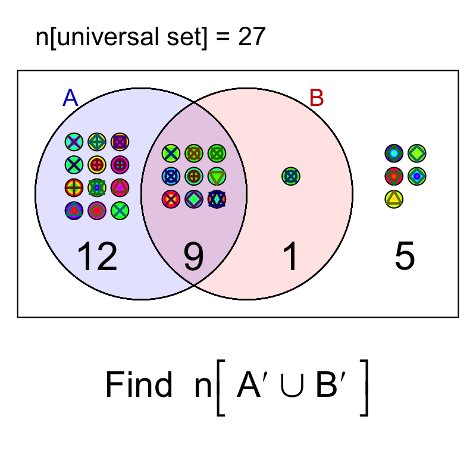

Find $n(A' ∪ B')$.

The answer is 18.

There are 23 tokens organized by 2 (not visible) attributes. Tokens with those attributes are categorized into subsets $A$ and $B$. Those subsets are visualized with a Venn diagram below. Each region's cardinality is shown.

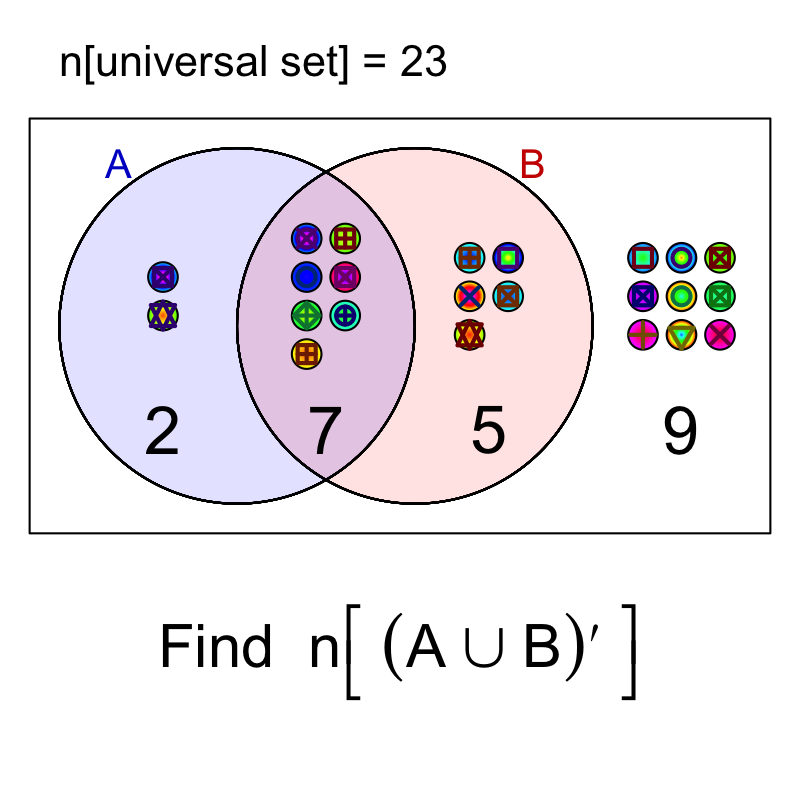

Find $n((A ∪ B)')$.

The answer is 9.

There are 25 tokens organized by 2 (not visible) attributes. Tokens with those attributes are categorized into subsets $A$ and $B$. Those subsets are visualized with a Venn diagram below. Each region's cardinality is shown.

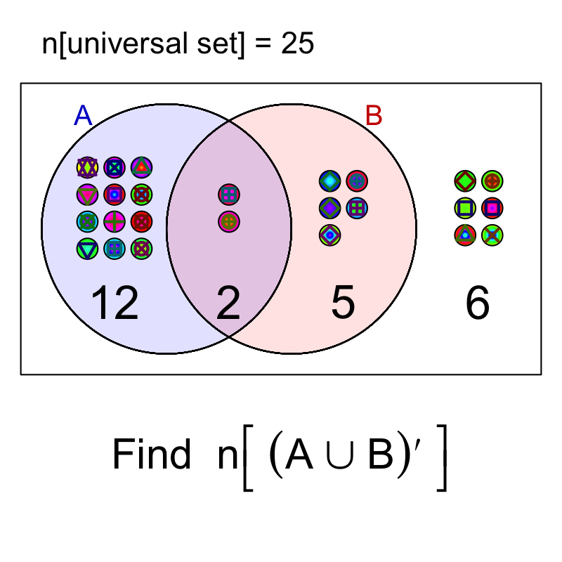

Find $n((A ∪ B)')$.

The answer is 6.

There are 31 tokens organized by 2 (not visible) attributes. Tokens with those attributes are categorized into subsets $A$ and $B$. Those subsets are visualized with a Venn diagram below. Each region's cardinality is shown.

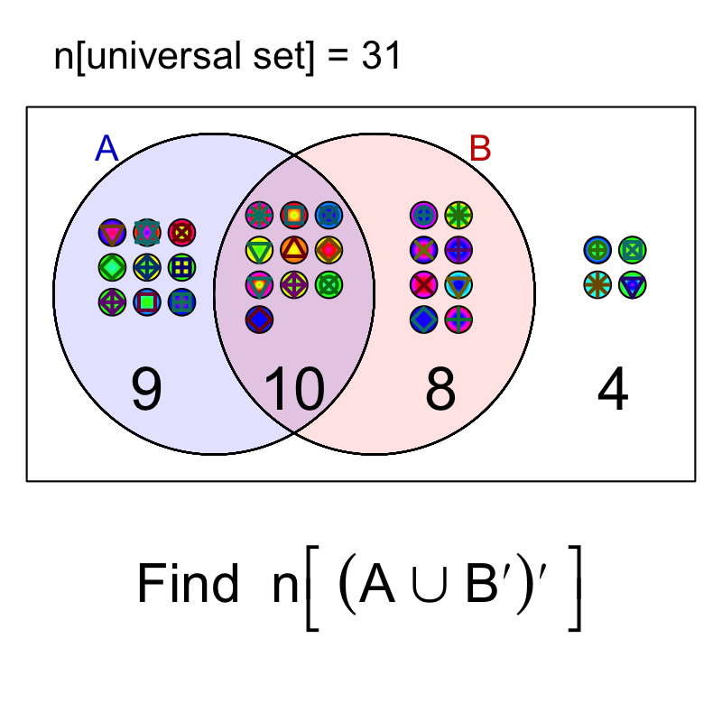

Find $n((A ∪ B')')$.

The answer is 8.

There are 19 tokens organized by 2 (not visible) attributes. Tokens with those attributes are categorized into subsets $A$ and $B$. Those subsets are visualized with a Venn diagram below. Each region's cardinality is shown.

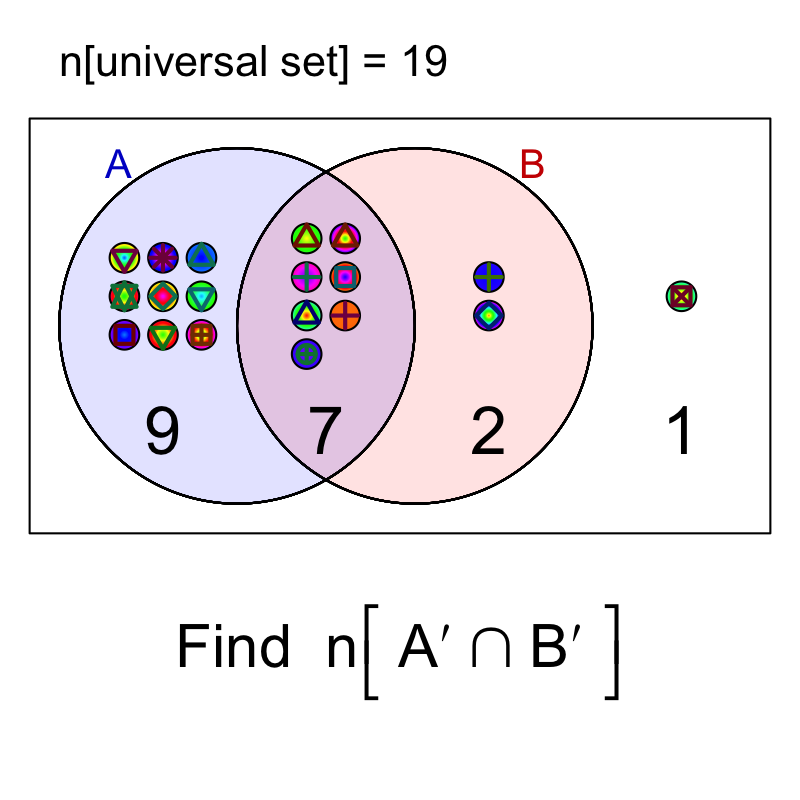

Find $n(A' ∩ B')$.

The answer is 1.

Let the cardinality of the universal set be 73.

$$n(U)=73$$

Three subsets, $A$, $B$, and $C$ are visualized with a Venn diagram below. Each region's cardinality is shown.

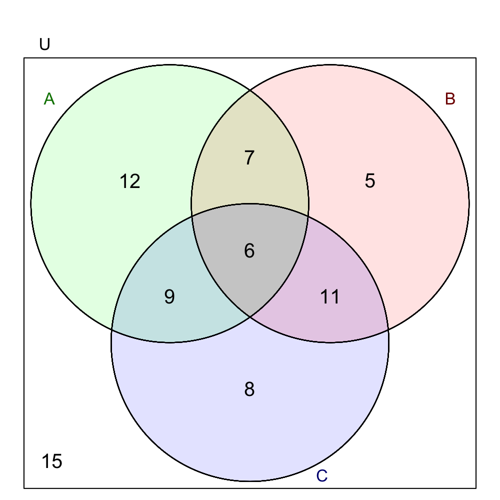

Find $n(B \cap C')$.

The answer is 12.

Let the cardinality of the universal set be 82.

$$n(U)=82$$

Three subsets, $A$, $B$, and $C$ are visualized with a Venn diagram below. Each region's cardinality is shown.

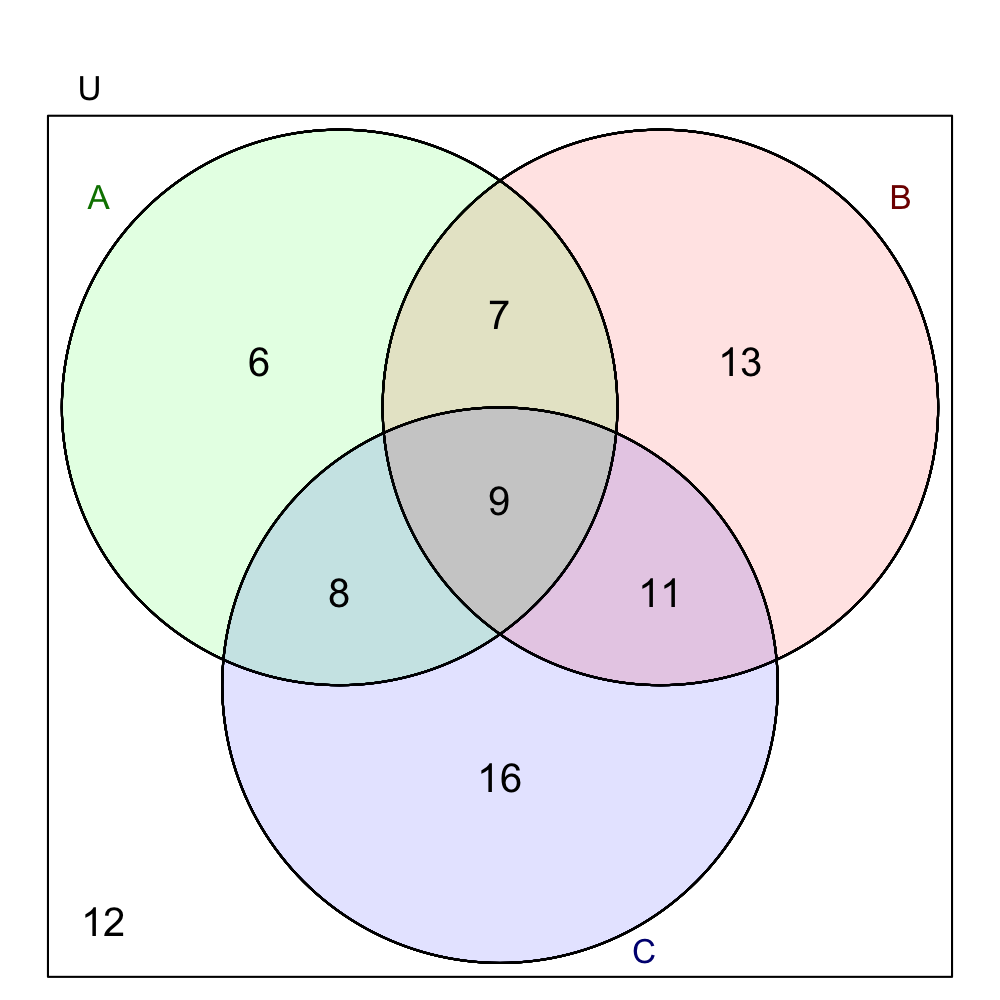

Find $n(A' \cap C')$.

The answer is 25.

Let the cardinality of the universal set be 96.

$$n(U)=96$$

Three subsets, $A$, $B$, and $C$ are visualized with a Venn diagram below. Each region's cardinality is shown.

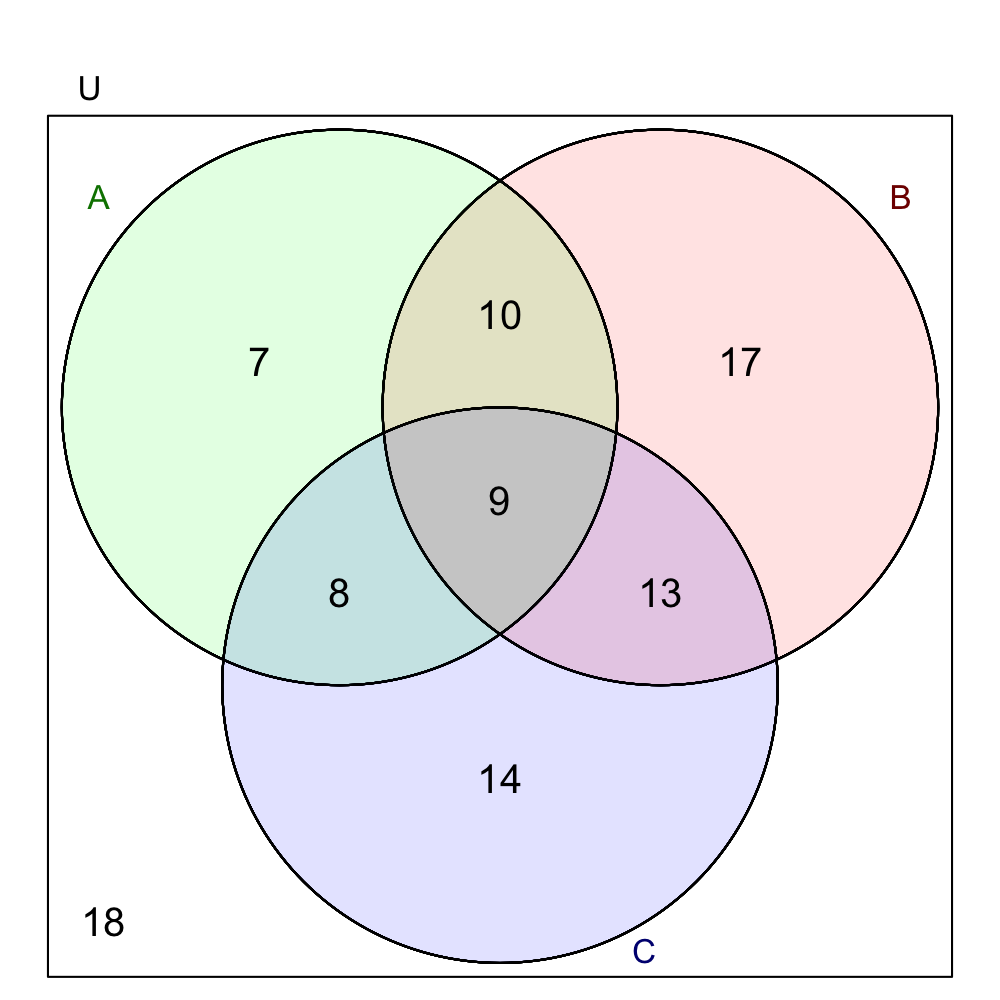

Find $n(B \cap C)$.

The answer is 22.

Let the cardinality of the universal set be 65.

$$n(U)=65$$

Three subsets, $A$, $B$, and $C$ are visualized with a Venn diagram below. Each region's cardinality is shown.

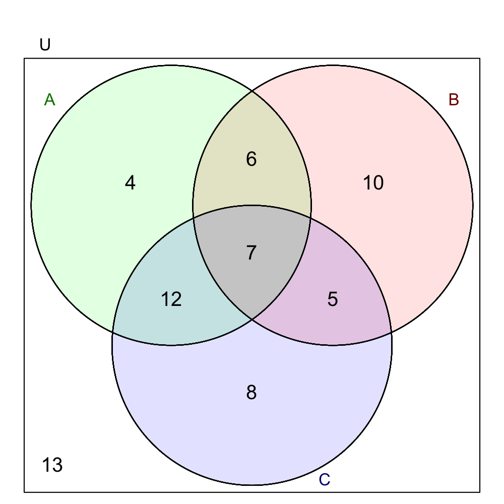

Find $n(A' \cap C)$.

The answer is 13.

Let the cardinality of the universal set be 72.

$$n(U)=72$$

Three subsets, $A$, $B$, and $C$ are visualized with a Venn diagram below. Each region's cardinality is shown.

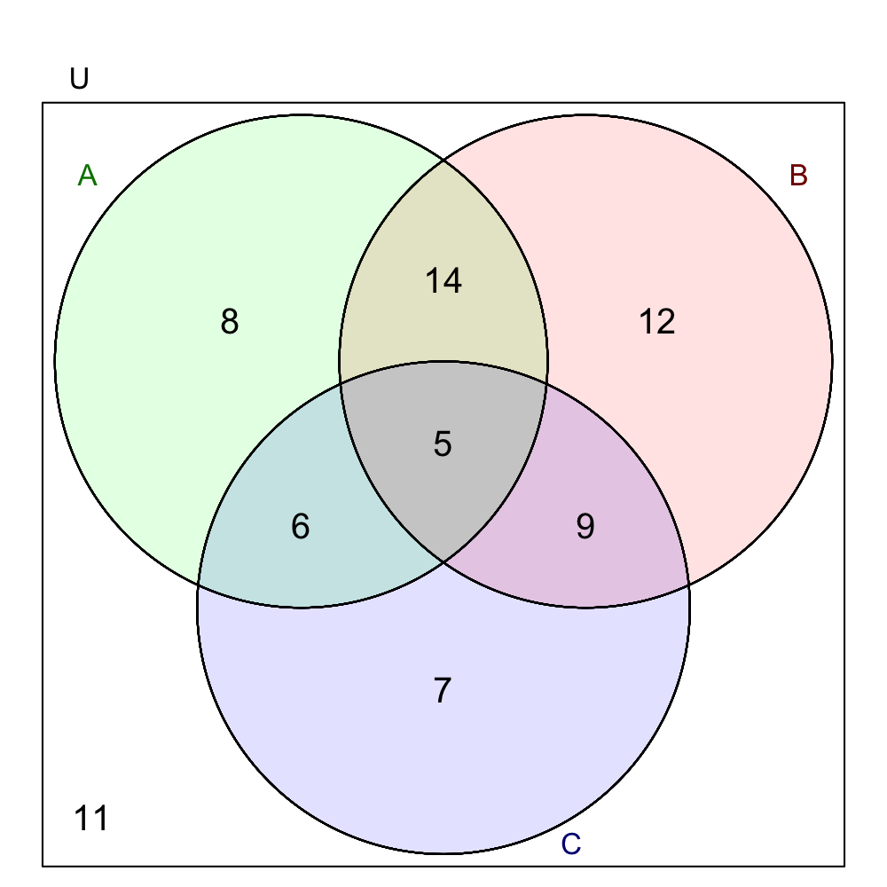

Find $n(A' \cap C)$.

The answer is 16.

Let the cardinality of the universal set be 68.

$$n(U)=68$$

Three subsets, $A$, $B$, and $C$ are visualized with a Venn diagram below. Each region's cardinality is shown.

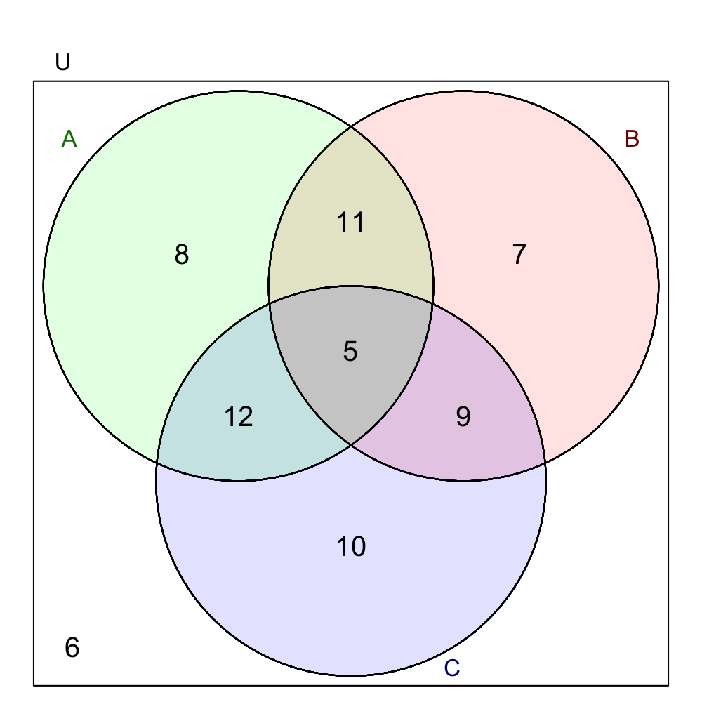

Find $n(A \cap B \cap C)$.

The answer is 5.

Let the cardinality of the universal set be 87.

$$n(U)=87$$

Three subsets, $A$, $B$, and $C$ are visualized with a Venn diagram below. Each region's cardinality is shown.

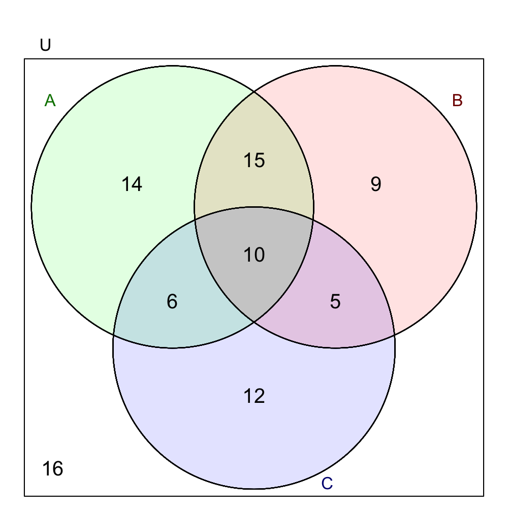

Find $n(B' \cap C')$.

The answer is 30.

Let the cardinality of the universal set be 83.

$$n(U)=83$$

Three subsets, $A$, $B$, and $C$ are visualized with a Venn diagram below. Each region's cardinality is shown.

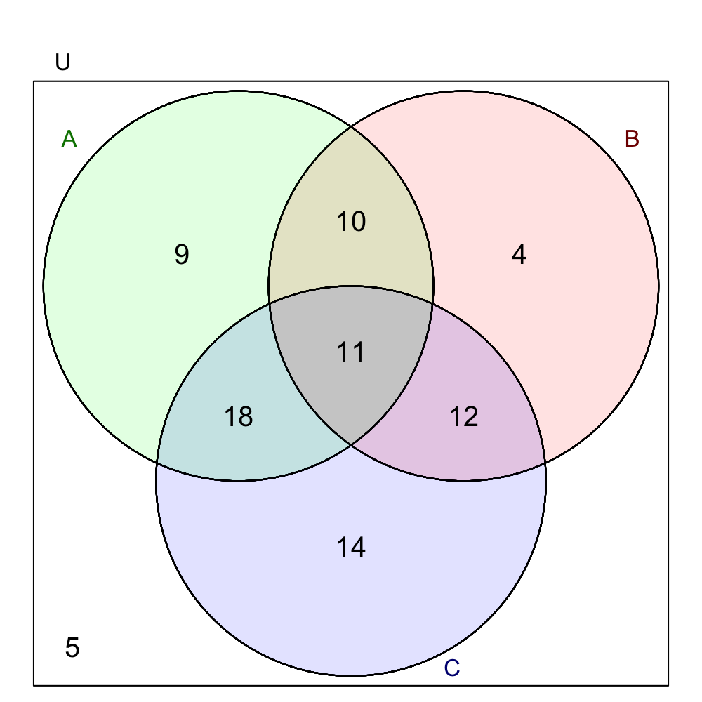

Find $n((A \cap B)')$.

The answer is 62.

Let the cardinality of the universal set be 91.

$$n(U)=91$$

Three subsets, $A$, $B$, and $C$ are visualized with a Venn diagram below. Each region's cardinality is shown.

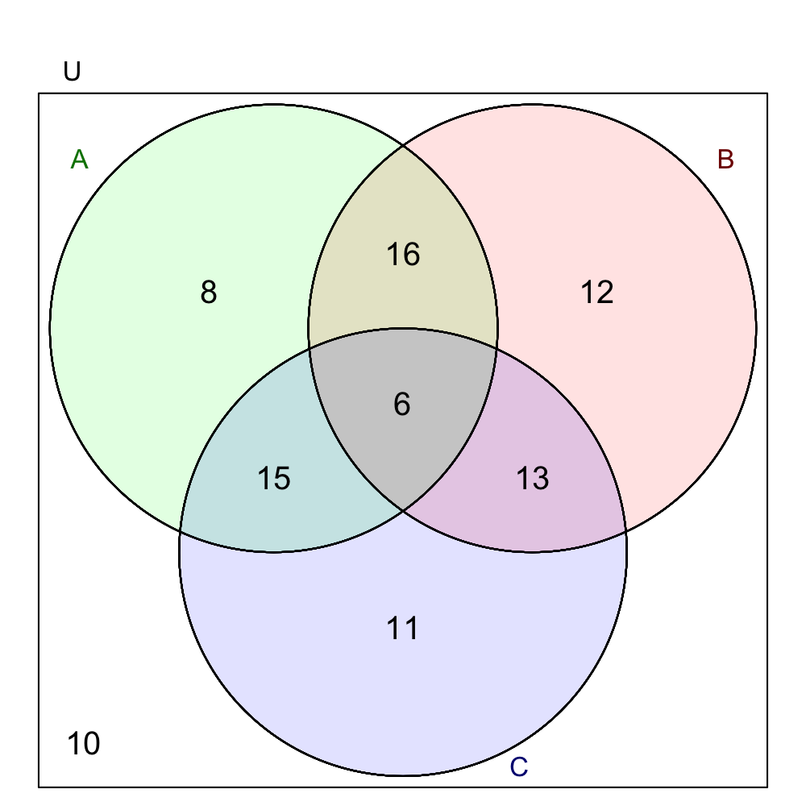

Find $n(B)$.

The answer is 47.

Let the cardinality of the universal set be 74.

$$n(U)=74$$

Three subsets, $A$, $B$, and $C$ are visualized with a Venn diagram below. Each region's cardinality is shown.

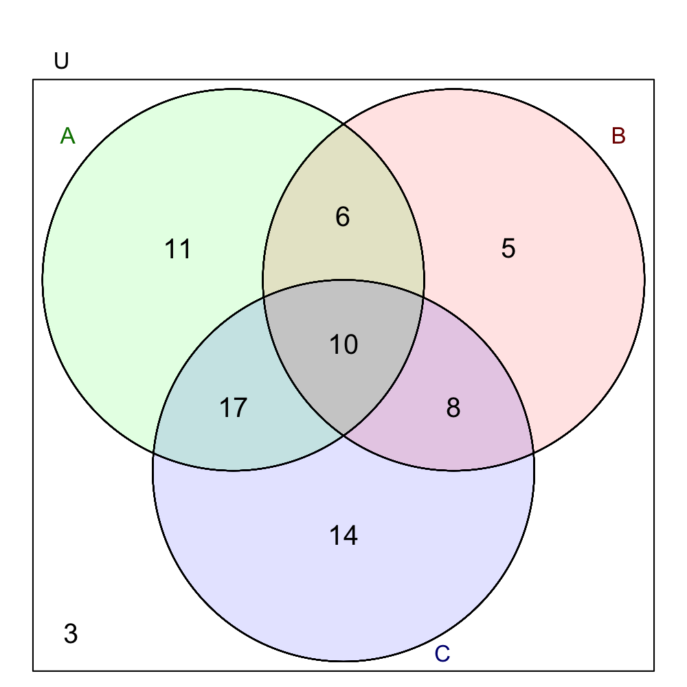

Find $n(A' \cap C')$.

The answer is 8.

Let $p$ represent the quantified logical statement below.

$$p: \text{ Some owls are
green.}$$

Which of the following represents the [negation](https://en.wikipedia.org/wiki/Negation#Negations_of_quantifiers) of $p$? In other words, which represents $\sim p$?

No owls are green.Some owls are green.Some owls are not green.All owls are green.

Let set $A$ represent the set of all things classified as owls.

Let set $B$ represent the set of all things classified as green.

Statement $p$ says that the intersection of $A$ and $B$ is not empty.

The logical negation, $\sim p$ would be that $A$ and $B$ are disjoint.

Thus,

$$\sim p: \text{ No owls are
green.}$$

Let $p$ represent the quantified logical statement below.

$$p: \text{ No apples are
enigmatic.}$$

Which of the following represents the [negation](https://en.wikipedia.org/wiki/Negation#Negations_of_quantifiers) of $p$? In other words, which represents $\sim p$?

Some apples are enigmatic.Some apples are not enigmatic.No apples are enigmatic.All apples are enigmatic.

Let set $A$ represent the set of all things classified as apples.

Let set $B$ represent the set of all things classified as enigmatic.

Statement $p$ says that $A$ and $B$ are disjoint.

The logical negation, $\sim p$ would be that the intersection of $A$ and $B$ is not empty.

Thus,

$$\sim p: \text{ Some apples are
enigmatic.}$$

Let $p$ represent the quantified logical statement below.

$$p: \text{ No jaguars are
weak.}$$

Which of the following represents the [negation](https://en.wikipedia.org/wiki/Negation#Negations_of_quantifiers) of $p$? In other words, which represents $\sim p$?

All jaguars are weak.Some jaguars are weak.No jaguars are weak.Some jaguars are not weak.

Let set $A$ represent the set of all things classified as jaguars.

Let set $B$ represent the set of all things classified as weak.

Statement $p$ says that $A$ and $B$ are disjoint.

The logical negation, $\sim p$ would be that the intersection of $A$ and $B$ is not empty.

Thus,

$$\sim p: \text{ Some jaguars are
weak.}$$

Let $p$ represent the quantified logical statement below.

$$p: \text{ Some apples are not
enigmatic.}$$

Which of the following represents the [negation](https://en.wikipedia.org/wiki/Negation#Negations_of_quantifiers) of $p$? In other words, which represents $\sim p$?

All apples are enigmatic.Some apples are enigmatic.No apples are enigmatic.Some apples are not enigmatic.

Let set $A$ represent the set of all things classified as apples.

Let set $B$ represent the set of all things classified as enigmatic.

Statement $p$ says that $A$ is not a subset of $B$.

The logical negation, $\sim p$ would be that $A$ is a subset of $B$.

Thus,

$$\sim p: \text{ All apples are
enigmatic.}$$

Let $p$ represent the quantified logical statement below.

$$p: \text{ All flowers are
blue.}$$

Which of the following represents the [negation](https://en.wikipedia.org/wiki/Negation#Negations_of_quantifiers) of $p$? In other words, which represents $\sim p$?

Some flowers are not blue.All flowers are blue.No flowers are blue.Some flowers are blue.

Let set $A$ represent the set of all things classified as flowers.

Let set $B$ represent the set of all things classified as blue.

Statement $p$ says that $A$ is a subset of $B$.

The logical negation, $\sim p$ would be that $A$ is not a subset of $B$.

Thus,

$$\sim p: \text{ Some flowers are not
blue.}$$

Let $p$ represent the quantified logical statement below.

$$p: \text{ No apples are
curious.}$$

Which of the following represents the [negation](https://en.wikipedia.org/wiki/Negation#Negations_of_quantifiers) of $p$? In other words, which represents $\sim p$?

All apples are curious.Some apples are curious.No apples are curious.Some apples are not curious.

Let set $A$ represent the set of all things classified as apples.

Let set $B$ represent the set of all things classified as curious.

Statement $p$ says that $A$ and $B$ are disjoint.

The logical negation, $\sim p$ would be that the intersection of $A$ and $B$ is not empty.

Thus,

$$\sim p: \text{ Some apples are
curious.}$$

Let $p$ represent the quantified logical statement below.

$$p: \text{ No owls are
zombies.}$$

Which of the following represents the [negation](https://en.wikipedia.org/wiki/Negation#Negations_of_quantifiers) of $p$? In other words, which represents $\sim p$?

No owls are zombies.Some owls are zombies.Some owls are not zombies.All owls are zombies.

Let set $A$ represent the set of all things classified as owls.

Let set $B$ represent the set of all things classified as zombies.

Statement $p$ says that $A$ and $B$ are disjoint.

The logical negation, $\sim p$ would be that the intersection of $A$ and $B$ is not empty.

Thus,

$$\sim p: \text{ Some owls are
zombies.}$$

Let $p$ represent the quantified logical statement below.

$$p: \text{ All kangaroos are
transient.}$$

Which of the following represents the [negation](https://en.wikipedia.org/wiki/Negation#Negations_of_quantifiers) of $p$? In other words, which represents $\sim p$?

Some kangaroos are transient.All kangaroos are transient.Some kangaroos are not transient.No kangaroos are transient.

Let set $A$ represent the set of all things classified as kangaroos.

Let set $B$ represent the set of all things classified as transient.

Statement $p$ says that $A$ is a subset of $B$.

The logical negation, $\sim p$ would be that $A$ is not a subset of $B$.

Thus,

$$\sim p: \text{ Some kangaroos are not
transient.}$$

Let $p$ represent the quantified logical statement below.

$$p: \text{ No whales are
lame.}$$

Which of the following represents the [negation](https://en.wikipedia.org/wiki/Negation#Negations_of_quantifiers) of $p$? In other words, which represents $\sim p$?

Some whales are lame.All whales are lame.No whales are lame.Some whales are not lame.

Let set $A$ represent the set of all things classified as whales.

Let set $B$ represent the set of all things classified as lame.

Statement $p$ says that $A$ and $B$ are disjoint.

The logical negation, $\sim p$ would be that the intersection of $A$ and $B$ is not empty.

Thus,

$$\sim p: \text{ Some whales are
lame.}$$

Let $p$ represent the quantified logical statement below.

$$p: \text{ No llamas are
outgoing.}$$

Which of the following represents the [negation](https://en.wikipedia.org/wiki/Negation#Negations_of_quantifiers) of $p$? In other words, which represents $\sim p$?

Some llamas are not outgoing.All llamas are outgoing.Some llamas are outgoing.No llamas are outgoing.

Let set $A$ represent the set of all things classified as llamas.

Let set $B$ represent the set of all things classified as outgoing.

Statement $p$ says that $A$ and $B$ are disjoint.

The logical negation, $\sim p$ would be that the intersection of $A$ and $B$ is not empty.

Thus,

$$\sim p: \text{ Some llamas are
outgoing.}$$

Complete the truth table for $p \land \sim q$.

| $p$ | $q$ | $p \land \sim q$ |
| --- | --- | --- |
| T | T |  |
| T | F |  |
| F | T |  |
| F | F |  |

| $p$ | $q$ | $p \land \sim q$ |
| --- | --- | --- |
| T | T | FALSE |
| T | F | TRUE |
| F | T | FALSE |
| F | F | FALSE |

Complete the truth table for $\sim (\sim p \land q)$.

| $p$ | $q$ | $\sim (\sim p \land q)$ |
| --- | --- | --- |
| T | T |  |
| T | F |  |
| F | T |  |
| F | F |  |

| $p$ | $q$ | $\sim (\sim p \land q)$ |
| --- | --- | --- |
| T | T | TRUE |
| T | F | TRUE |
| F | T | FALSE |
| F | F | TRUE |

Complete the truth table for $\sim (\sim p \land \sim q)$.

| $p$ | $q$ | $\sim (\sim p \land \sim q)$ |
| --- | --- | --- |
| T | T |  |
| T | F |  |
| F | T |  |
| F | F |  |

| $p$ | $q$ | $\sim (\sim p \land \sim q)$ |
| --- | --- | --- |
| T | T | TRUE |
| T | F | TRUE |
| F | T | TRUE |
| F | F | FALSE |

Complete the truth table for $p \lor q$.

| $p$ | $q$ | $p \lor q$ |
| --- | --- | --- |
| T | T |  |
| T | F |  |
| F | T |  |
| F | F |  |

| $p$ | $q$ | $p \lor q$ |
| --- | --- | --- |
| T | T | TRUE |
| T | F | TRUE |
| F | T | TRUE |
| F | F | FALSE |

Complete the truth table for $\sim (\sim p \land \sim q)$.

| $p$ | $q$ | $\sim (\sim p \land \sim q)$ |
| --- | --- | --- |
| T | T |  |
| T | F |  |
| F | T |  |
| F | F |  |

| $p$ | $q$ | $\sim (\sim p \land \sim q)$ |
| --- | --- | --- |
| T | T | TRUE |
| T | F | TRUE |
| F | T | TRUE |
| F | F | FALSE |

Complete the truth table for $\sim (p \lor \sim q)$.

| $p$ | $q$ | $\sim (p \lor \sim q)$ |
| --- | --- | --- |
| T | T |  |
| T | F |  |
| F | T |  |
| F | F |  |

| $p$ | $q$ | $\sim (p \lor \sim q)$ |
| --- | --- | --- |
| T | T | FALSE |
| T | F | FALSE |
| F | T | TRUE |
| F | F | FALSE |

Complete the truth table for $\sim p \land \sim q$.

| $p$ | $q$ | $\sim p \land \sim q$ |
| --- | --- | --- |
| T | T |  |
| T | F |  |
| F | T |  |
| F | F |  |

| $p$ | $q$ | $\sim p \land \sim q$ |
| --- | --- | --- |
| T | T | FALSE |
| T | F | FALSE |
| F | T | FALSE |
| F | F | TRUE |

Complete the truth table for $p \land \sim q$.

| $p$ | $q$ | $p \land \sim q$ |
| --- | --- | --- |
| T | T |  |
| T | F |  |
| F | T |  |
| F | F |  |

| $p$ | $q$ | $p \land \sim q$ |
| --- | --- | --- |
| T | T | FALSE |
| T | F | TRUE |
| F | T | FALSE |
| F | F | FALSE |

Complete the truth table for $\sim (p \lor \sim q)$.

| $p$ | $q$ | $\sim (p \lor \sim q)$ |
| --- | --- | --- |
| T | T |  |
| T | F |  |
| F | T |  |
| F | F |  |

| $p$ | $q$ | $\sim (p \lor \sim q)$ |
| --- | --- | --- |
| T | T | FALSE |
| T | F | FALSE |
| F | T | TRUE |
| F | F | FALSE |

Complete the truth table for $\sim p \lor q$.

| $p$ | $q$ | $\sim p \lor q$ |
| --- | --- | --- |
| T | T |  |
| T | F |  |
| F | T |  |
| F | F |  |

| $p$ | $q$ | $\sim p \lor q$ |
| --- | --- | --- |
| T | T | TRUE |
| T | F | FALSE |
| F | T | TRUE |
| F | F | TRUE |

A conditional statement is stated below:

> - If bugs are enigmatic, then umbrellas are NOT green.

Label each of the [variations](https://en.wikipedia.org/wiki/Contraposition):

1. If bugs are NOT enigmatic, then umbrellas are green.
2. If umbrellas are green, then bugs are NOT enigmatic.
3. If umbrellas are NOT green, then bugs are enigmatic.
- Which variation is logically equivalent to the original?

If the original conditional statement is $p\to q$, then:

- Contrapositive is $\sim q \to \sim p$
- Converse is $q \to p$
- Inverse is $\sim p \to \sim q$

And the contrapositive is always logically equivalent to the original conditional statement.

In this case the original conditional statement was:

> - If bugs are enigmatic, then umbrellas are NOT green.
- The contrapositive would be:
  - If umbrellas are green, then bugs are NOT enigmatic.
- The converse would be:
  - If umbrellas are NOT green, then bugs are enigmatic.
- The inverse would be:
  - If bugs are NOT enigmatic, then umbrellas are green.

Thus, (1) is the inverse, and (2) is the contrapositive, and (3) is the converse. And so (2) is the logically equivalent statement.

A conditional statement is stated below:

> - If flowers are NOT enigmatic, then violins are NOT green.

Label each of the [variations](https://en.wikipedia.org/wiki/Contraposition):

1. If violins are green, then flowers are enigmatic.
2. If flowers are enigmatic, then violins are green.
3. If violins are NOT green, then flowers are NOT enigmatic.
- Which variation is logically equivalent to the original?

If the original conditional statement is $p\to q$, then:

- Contrapositive is $\sim q \to \sim p$
- Converse is $q \to p$
- Inverse is $\sim p \to \sim q$

And the contrapositive is always logically equivalent to the original conditional statement.

In this case the original conditional statement was:

> - If flowers are NOT enigmatic, then violins are NOT green.
- The contrapositive would be:
  - If violins are green, then flowers are enigmatic.
- The converse would be:
  - If violins are NOT green, then flowers are NOT enigmatic.
- The inverse would be:
  - If flowers are enigmatic, then violins are green.

Thus, (1) is the contrapositive, and (2) is the inverse, and (3) is the converse. And so (1) is the logically equivalent statement.

A conditional statement is stated below:

> - If bugs are green, then elephants are NOT yellow.

Label each of the [variations](https://en.wikipedia.org/wiki/Contraposition):

1. If elephants are yellow, then bugs are NOT green.
2. If elephants are NOT yellow, then bugs are green.
3. If bugs are NOT green, then elephants are yellow.
- Which variation is logically equivalent to the original?

If the original conditional statement is $p\to q$, then:

- Contrapositive is $\sim q \to \sim p$
- Converse is $q \to p$
- Inverse is $\sim p \to \sim q$

And the contrapositive is always logically equivalent to the original conditional statement.

In this case the original conditional statement was:

> - If bugs are green, then elephants are NOT yellow.
- The contrapositive would be:
  - If elephants are yellow, then bugs are NOT green.
- The converse would be:
  - If elephants are NOT yellow, then bugs are green.
- The inverse would be:
  - If bugs are NOT green, then elephants are yellow.

Thus, (1) is the contrapositive, and (2) is the converse, and (3) is the inverse. And so (1) is the logically equivalent statement.

A conditional statement is stated below:

> - If elephants are green, then violins are blue.

Label each of the [variations](https://en.wikipedia.org/wiki/Contraposition):

1. If violins are NOT blue, then elephants are NOT green.
2. If violins are blue, then elephants are green.
3. If elephants are NOT green, then violins are NOT blue.
- Which variation is logically equivalent to the original?

If the original conditional statement is $p\to q$, then:

- Contrapositive is $\sim q \to \sim p$
- Converse is $q \to p$
- Inverse is $\sim p \to \sim q$

And the contrapositive is always logically equivalent to the original conditional statement.

In this case the original conditional statement was:

> - If elephants are green, then violins are blue.
- The contrapositive would be:
  - If violins are NOT blue, then elephants are NOT green.
- The converse would be:
  - If violins are blue, then elephants are green.
- The inverse would be:
  - If elephants are NOT green, then violins are NOT blue.

Thus, (1) is the contrapositive, and (2) is the converse, and (3) is the inverse. And so (1) is the logically equivalent statement.

A conditional statement is stated below:

> - If quokkas are lame, then hawks are NOT nice.

Label each of the [variations](https://en.wikipedia.org/wiki/Contraposition):

1. If hawks are NOT nice, then quokkas are lame.
2. If hawks are nice, then quokkas are NOT lame.
3. If quokkas are NOT lame, then hawks are nice.
- Which variation is logically equivalent to the original?

If the original conditional statement is $p\to q$, then:

- Contrapositive is $\sim q \to \sim p$
- Converse is $q \to p$
- Inverse is $\sim p \to \sim q$

And the contrapositive is always logically equivalent to the original conditional statement.

In this case the original conditional statement was:

> - If quokkas are lame, then hawks are NOT nice.
- The contrapositive would be:
  - If hawks are nice, then quokkas are NOT lame.
- The converse would be:
  - If hawks are NOT nice, then quokkas are lame.
- The inverse would be:
  - If quokkas are NOT lame, then hawks are nice.

Thus, (1) is the converse, and (2) is the contrapositive, and (3) is the inverse. And so (2) is the logically equivalent statement.

A conditional statement is stated below:

> - If elephants are NOT menacing, then apples are NOT xenophobic.

Label each of the [variations](https://en.wikipedia.org/wiki/Contraposition):

1. If elephants are menacing, then apples are xenophobic.
2. If apples are xenophobic, then elephants are menacing.
3. If apples are NOT xenophobic, then elephants are NOT menacing.
- Which variation is logically equivalent to the original?

If the original conditional statement is $p\to q$, then:

- Contrapositive is $\sim q \to \sim p$
- Converse is $q \to p$
- Inverse is $\sim p \to \sim q$

And the contrapositive is always logically equivalent to the original conditional statement.

In this case the original conditional statement was:

> - If elephants are NOT menacing, then apples are NOT xenophobic.
- The contrapositive would be:
  - If apples are xenophobic, then elephants are menacing.
- The converse would be:
  - If apples are NOT xenophobic, then elephants are NOT menacing.
- The inverse would be:
  - If elephants are menacing, then apples are xenophobic.

Thus, (1) is the inverse, and (2) is the contrapositive, and (3) is the converse. And so (2) is the logically equivalent statement.

A conditional statement is stated below:

> - If kangaroos are transient, then zebras are awesome.

Label each of the [variations](https://en.wikipedia.org/wiki/Contraposition):

1. If zebras are awesome, then kangaroos are transient.
2. If kangaroos are NOT transient, then zebras are NOT awesome.
3. If zebras are NOT awesome, then kangaroos are NOT transient.
- Which variation is logically equivalent to the original?

If the original conditional statement is $p\to q$, then:

- Contrapositive is $\sim q \to \sim p$
- Converse is $q \to p$
- Inverse is $\sim p \to \sim q$

And the contrapositive is always logically equivalent to the original conditional statement.

In this case the original conditional statement was:

> - If kangaroos are transient, then zebras are awesome.
- The contrapositive would be:
  - If zebras are NOT awesome, then kangaroos are NOT transient.
- The converse would be:
  - If zebras are awesome, then kangaroos are transient.
- The inverse would be:
  - If kangaroos are NOT transient, then zebras are NOT awesome.

Thus, (1) is the converse, and (2) is the inverse, and (3) is the contrapositive. And so (3) is the logically equivalent statement.

A conditional statement is stated below:

> - If dogs are dangerous, then giraffes are green.

Label each of the [variations](https://en.wikipedia.org/wiki/Contraposition):

1. If giraffes are green, then dogs are dangerous.
2. If giraffes are NOT green, then dogs are NOT dangerous.
3. If dogs are NOT dangerous, then giraffes are NOT green.
- Which variation is logically equivalent to the original?

If the original conditional statement is $p\to q$, then:

- Contrapositive is $\sim q \to \sim p$
- Converse is $q \to p$
- Inverse is $\sim p \to \sim q$

And the contrapositive is always logically equivalent to the original conditional statement.

In this case the original conditional statement was:

> - If dogs are dangerous, then giraffes are green.
- The contrapositive would be:
  - If giraffes are NOT green, then dogs are NOT dangerous.
- The converse would be:
  - If giraffes are green, then dogs are dangerous.
- The inverse would be:
  - If dogs are NOT dangerous, then giraffes are NOT green.

Thus, (1) is the converse, and (2) is the contrapositive, and (3) is the inverse. And so (2) is the logically equivalent statement.

A conditional statement is stated below:

> - If violins are NOT sly, then llamas are NOT weak.

Label each of the [variations](https://en.wikipedia.org/wiki/Contraposition):

1. If llamas are weak, then violins are sly.
2. If llamas are NOT weak, then violins are NOT sly.
3. If violins are sly, then llamas are weak.
- Which variation is logically equivalent to the original?

If the original conditional statement is $p\to q$, then:

- Contrapositive is $\sim q \to \sim p$
- Converse is $q \to p$
- Inverse is $\sim p \to \sim q$

And the contrapositive is always logically equivalent to the original conditional statement.

In this case the original conditional statement was:

> - If violins are NOT sly, then llamas are NOT weak.
- The contrapositive would be:
  - If llamas are weak, then violins are sly.
- The converse would be:
  - If llamas are NOT weak, then violins are NOT sly.
- The inverse would be:
  - If violins are sly, then llamas are weak.

Thus, (1) is the contrapositive, and (2) is the converse, and (3) is the inverse. And so (1) is the logically equivalent statement.

A conditional statement is stated below:

> - If mice are furious, then bugs are enigmatic.

Label each of the [variations](https://en.wikipedia.org/wiki/Contraposition):

1. If bugs are enigmatic, then mice are furious.
2. If mice are NOT furious, then bugs are NOT enigmatic.
3. If bugs are NOT enigmatic, then mice are NOT furious.
- Which variation is logically equivalent to the original?

If the original conditional statement is $p\to q$, then:

- Contrapositive is $\sim q \to \sim p$
- Converse is $q \to p$
- Inverse is $\sim p \to \sim q$

And the contrapositive is always logically equivalent to the original conditional statement.

In this case the original conditional statement was:

> - If mice are furious, then bugs are enigmatic.
- The contrapositive would be:
  - If bugs are NOT enigmatic, then mice are NOT furious.
- The converse would be:
  - If bugs are enigmatic, then mice are furious.
- The inverse would be:
  - If mice are NOT furious, then bugs are NOT enigmatic.

Thus, (1) is the converse, and (2) is the inverse, and (3) is the contrapositive. And so (3) is the logically equivalent statement.